# Bike Sharing Demand

## Introduction

We have to predict the total count of bikes rented during each hour covered by the test set, using only information available prior to the rental period.

```r
require(plyr)
detach(package:plyr)
library(dplyr)
library(tidyr)
library(ggplot2)
library(stringr)
library(caret)
library(randomForest)
library(lubridate)
library(scales)
library(ggcorrplot)
library(parallel)
library(doParallel)
```

```r
train.data <- tbl_df(read.csv('./Input/train.csv', stringsAsFactors = F))
test.data <- tbl_df(read.csv('./Input/test.csv', stringsAsFactors = F))
```

## Data Pre-processing, Cleaning & Feature Extraction

Replacing season codes with corresponding values.

```r
season.list <- c('spring', 'summer', 'fall', 'winter')
replace_season <- function(df){
    df[['season']] <- plyr::mapvalues(df[['season']],
                                  from = c(1, 2, 3, 4),
                                  to = season.list)
    return(df)
}
train.data <- replace_season(train.data)
```

Creating Weather matrix as follows:  
weather 1: clear, partly_cloudy,  
weather 2: mist, cloudy, partly_cloudy  
weather 3: light_snow_rain, thunderstorm, partly_cloudy  
weather 4: heavy_snow_rain_ice_fog, mist, thunderstorm

```r
train.data <- train.data %>%
    mutate(clear = 0, partly_cloudy = 0, mist = 0, cloudy = 0,
           light_snow_rain = 0, thunderstorm = 0, heavy_snow_rain_ice_fog = 0)
weather_matrix <- function(df){
    df[['clear']]                   <- ifelse(df[['weather']] == 1, 1, 0)
    df[['partly_cloudy']]           <- ifelse(df[['weather']] %in% c(1, 2, 3), 1, 0)
    df[['mist']]                    <- ifelse(df[['weather']] %in% c(2, 4), 1, 0)
    df[['cloudy']]                  <- ifelse(df[['weather']] == 2, 1, 0)
    df[['light_snow_rain']]         <- ifelse(df[['weather']] == 3, 1, 0)
    df[['thunderstorm']]            <- ifelse(df[['weather']] %in% c(3, 4), 1, 0)
    df[['heavy_snow_rain_ice_fog']] <- ifelse(df[['weather']] == 4, 1, 0)

    return(df)
}
train.data <- weather_matrix(train.data)
```

Splitting datetime into year, month, day_num, day_name, hour

```r
train.data <- train.data %>%
    mutate(date.year = 0, date.month = '', month.day = 0,
           week.day = '', day.hour = 0)
split_date <- function(df){
    df[['date.year']] = year(df[['datetime']])
    df[['date.month']] = month(df[['datetime']], label = T)
    df[['month.day']] = day(df[['datetime']])
    df[['week.day']] = wday(df[['datetime']], label = T)
    df[['day.hour']] = hour(df[['datetime']])

    return(df)
}
train.data <- split_date(train.data)
```

Adding new column, temp.diff <- atemp - temp

```r
train.data <- train.data %>%
    mutate(temp.diff = atemp - temp)
```

Adding new column, day.type – working day, holiday or weekend

```r
train.data <- train.data %>%
    mutate(day.type = NA)
day_type <- function(df){
    df[['day.type']] <- ifelse(df[['holiday']] == 1, 'Holiday',
                               ifelse(df[['workingday']] == 1, 'Workingday',
                                      'Weekend'))
    return(df)
}
train.data <- day_type(train.data)
```

Converting columns into factors

```r
train.data[c(2:5, 13:24, 26)] <- lapply(train.data[c(2:5, 13:24, 26)], factor)
```

Now lets check the data again

```r
summary(train.data)
```

```
   datetime            season     holiday   workingday weather       temp
 Length:10886       fall  :2733   0:10575   0:3474     1:7192   Min.   : 0.82
 Class :character   spring:2686   1:  311   1:7412     2:2834   1st Qu.:13.94
 Mode  :character   summer:2733                        3: 859   Median :20.50
                    winter:2734                        4:   1   Mean   :20.23
                                                                3rd Qu.:26.24
                                                                Max.   :41.00

     atemp          humidity        windspeed          casual
 Min.   : 0.76   Min.   :  0.00   Min.   : 0.000   Min.   :  0.00
 1st Qu.:16.66   1st Qu.: 47.00   1st Qu.: 7.002   1st Qu.:  4.00
 Median :24.24   Median : 62.00   Median :12.998   Median : 17.00
 Mean   :23.66   Mean   : 61.89   Mean   :12.799   Mean   : 36.02
 3rd Qu.:31.06   3rd Qu.: 77.00   3rd Qu.:16.998   3rd Qu.: 49.00
 Max.   :45.45   Max.   :100.00   Max.   :56.997   Max.   :367.00

   registered        count       clear    partly_cloudy mist     cloudy
 Min.   :  0.0   Min.   :  1.0   0:3694   0:    1       0:8051   0:8052
 1st Qu.: 36.0   1st Qu.: 42.0   1:7192   1:10885       1:2835   1:2834
 Median :118.0   Median :145.0
 Mean   :155.6   Mean   :191.6
 3rd Qu.:222.0   3rd Qu.:284.0
 Max.   :886.0   Max.   :977.0

 light_snow_rain thunderstorm heavy_snow_rain_ice_fog date.year
 0:10027         0:10026      0:10885                 2011:5422
 1:  859         1:  860      1:    1                 2012:5464





   date.month     month.day     week.day       day.hour      temp.diff
 May    : 912   1      : 575   Sun  :1579   12     : 456   Min.   :-23.140
 Jun    : 912   5      : 575   Mon  :1551   13     : 456   1st Qu.:  2.745
 Jul    : 912   9      : 575   Tues :1539   14     : 456   Median :  3.680
 Aug    : 912   17     : 575   Wed  :1551   15     : 456   Mean   :  3.424
 Dec    : 912   4      : 574   Thurs:1553   16     : 456   3rd Qu.:  4.055
 Oct    : 911   7      : 574   Fri  :1529   17     : 456   Max.   :  8.045
 (Other):5415   (Other):7438   Sat  :1584   (Other):8150
       day.type
 Holiday   : 311
 Weekend   :3163
 Workingday:7412
```

## Data Exploration

First lets check the proportion of casual to registered users

```r
train.data %>% mutate(casual.users = sum(casual),
                      registered.users = sum(registered)) %>%
    select(casual.users, registered.users) %>%
    distinct(casual.users, registered.users) %>%
    prop.table()
```

| casual.users | registered.users |
| --- | --- |
| 0.1880314 | 0.8119686 |

### No. of Users by Season

Lets check the effect of seasons on the users

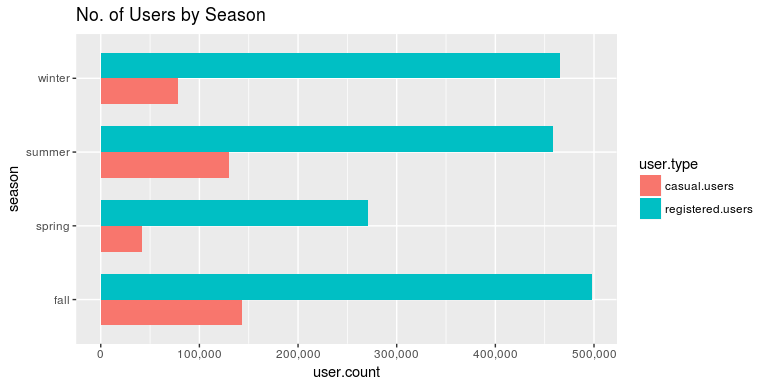

```r
users.by.season <- train.data %>%
    group_by(season) %>%
    mutate(casual.users = sum(casual),
           registered.users = sum(registered)) %>%
    select(season, casual.users, registered.users) %>%
    distinct(season, casual.users, registered.users) %>%
    gather(key = user.type, value = user.count, casual.users:registered.users)
plot.users.by.season <- ggplot(users.by.season,
                          mapping = aes(season, user.count,
                                        fill = user.type)) +
    geom_bar(stat = 'identity', position = 'dodge', width = 0.7) +
    scale_y_continuous(labels = comma) +
    coord_flip() +
    ggtitle('No. of Users by Season')
plot.users.by.season
```

It seems less people ride bicycles during Spring season than other seasons.

In winter and spring the proportion of casual users decreases in comparision to registered users.

### No. of Users by Weather

Lets check the user count by weather

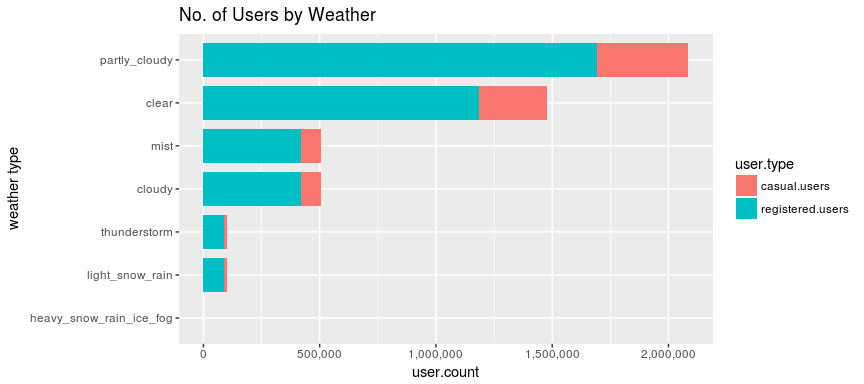

```r
users.by.weather <- train.data %>%
    gather(key = weather.type, value = value,
           clear:heavy_snow_rain_ice_fog) %>%
    filter(value > 0) %>%
    group_by(weather.type) %>%
    mutate(casual.users = sum(casual),
           registered.users = sum(registered)) %>%
    select(weather.type, casual.users, registered.users) %>%
    distinct(weather.type, casual.users, registered.users) %>%
    gather(key = user.type, value = user.count,
           casual.users:registered.users)
plot.users.by.weather <- ggplot(users.by.weather,
                          mapping = aes(reorder(weather.type, user.count),
                                        user.count, fill = user.type)) +
    geom_bar(stat = 'identity', width = 0.8) +
    scale_y_continuous(labels = comma) +
    coord_flip() +
    xlab('weather type') +
    ggtitle('No. of Users by Weather')
plot.users.by.weather
```

Most people ride during good weather (Clear, Partly Cloudy). Only the most dedicated ride in bad weather (Thunderstorm, Light snow or Rain).

### No. of Users over Days of Week

Lets check user count over days of week

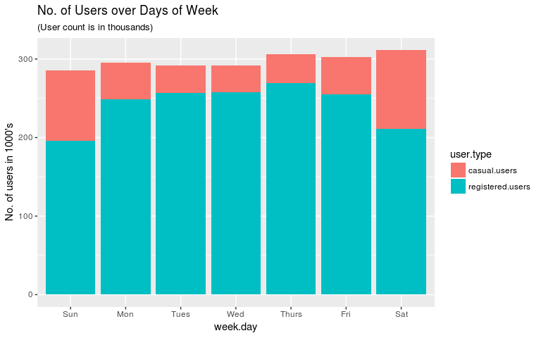

```r
users.over.days.of.week <- train.data %>%
    group_by(week.day) %>%
    mutate(casual.users = sum(casual),
           registered.users = sum(registered)) %>%
    select(week.day, casual.users, registered.users) %>%
    distinct(week.day, casual.users, registered.users) %>%
    gather(key = user.type, value = user.count,
           casual.users:registered.users)
plot.users.over.days.of.week <-
    ggplot(users.over.days.of.week,
           mapping = aes(x = week.day, y = user.count/1000,
                         fill = user.type)) +
    geom_bar(stat = 'identity') +
    ylab('No. of users in 1000\'s') +
    ggtitle(label = 'No. of Users over Days of Week',
            subtitle = '(User count is in thousands)')
plot.users.over.days.of.week
```

While the overall count of users remains pretty much the same over the week, more casual users ride bicycles on weekends; and the registered users prefer to ride during the weekdays.

### No. of Users based on Hour of Day

Lets check what time of the day most users ride.

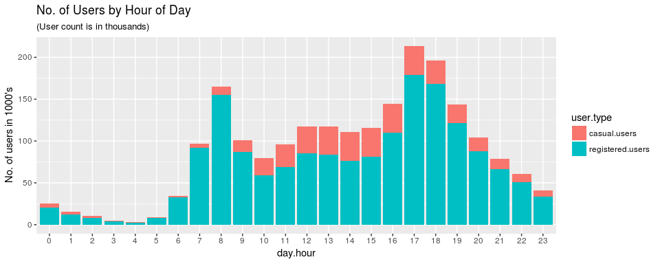

```r
users.by.hour.of.day <- train.data %>%
    group_by(day.hour) %>%
    mutate(casual.users = sum(casual),
           registered.users = sum(registered)) %>%
    select(day.hour, casual.users, registered.users) %>%
    distinct(day.hour, casual.users, registered.users) %>%
    gather(key = user.type, value = user.count,
           casual.users:registered.users)
plot.users.by.hour.of.day <-
    ggplot(users.by.hour.of.day,
           mapping = aes(x = day.hour, y = user.count/1000,
                         fill = user.type)) +
    geom_bar(stat = 'identity') +
    ylab('No. of users in 1000\'s') +
    ggtitle(label = 'No. of Users by Hour of Day',
            subtitle = '(User count is in thousands)')
plot.users.by.hour.of.day
```

As expected, most users ride between 6 AM to 11 PM. The bicycle use peaks at 8 AM and between 4 PM to 7 PM.

### No. of Users based on Hour of Day by Season

Lets see if the usage pattern changes in different seasons.

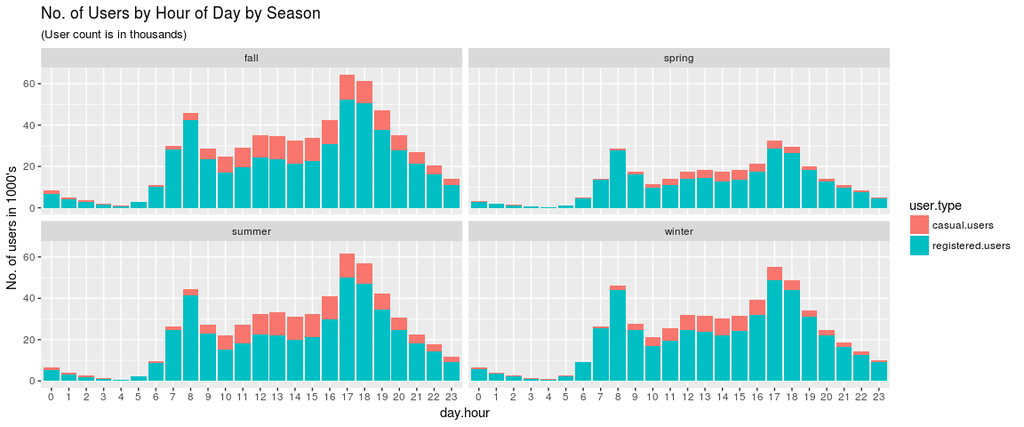

```r
users.by.hour.of.day.by.season <- train.data %>%
    group_by(season, day.hour) %>%
    mutate(casual.users = sum(casual),
           registered.users = sum(registered)) %>%
    select(season, day.hour, casual.users, registered.users) %>%
    distinct(season, day.hour, casual.users, registered.users) %>%
    gather(key = user.type, value = user.count,
           casual.users:registered.users)
plot.users.by.hour.of.day.by.season <-
    ggplot(users.by.hour.of.day.by.season,
           mapping = aes(x = day.hour, y = user.count/1000,
                         fill = user.type)) +
    geom_bar(stat = 'identity') +
    facet_wrap(~ season) +
    ylab('No. of users in 1000\'s') +
    ggtitle(label = 'No. of Users by Hour of Day by Season',
            subtitle = '(User count is in thousands)')
plot.users.by.hour.of.day.by.season
```

Nothing new here. We already knew that there are less users overall during Spring. The usage pattern by hour of day is same in all 4 seasons.

### Correlaton between Temperature, Humidity, Windspeed and User Count

Lets see the correlation between Temperature, Humidity, Windspeed and User Count.

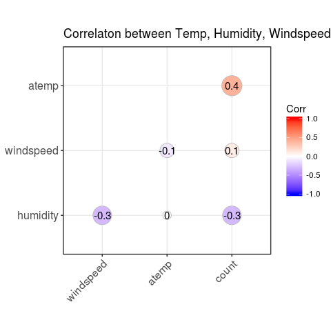

```r
corr.temp.hum.wind.user <- train.data %>%
    select(atemp, humidity, windspeed, count) %>%
    distinct() %>% cor() %>% round(digits = 1)
plot.corr.temp.hum.wind.user <-
    ggcorrplot(corr = corr.temp.hum.wind.user, method = 'circle',
               type = 'lower', hc.order = T, lab = T, lab_size = 4,
               ggtheme = theme_bw,
               title = 'Correlaton between Temp, Humidity, Windspeed & UserCount')
plot.corr.temp.hum.wind.user
```

User Count seems to have positive correlation to Temperature and negative to humidity.

## Model Training, Prediction & Evaluation - 1

We will use Random Forest to train our model.

Preparing the feature dataset.

```r
feature.train <- train.data %>%
    select(season, atemp, humidity, windspeed, clear, partly_cloudy,
           mist, cloudy, light_snow_rain, thunderstorm, heavy_snow_rain_ice_fog,
           date.year, date.month, month.day, week.day, day.hour, day.type,
           count) %>%
    distinct()
```

Splitting training and testing datasets

```r
set.seed(777)
inTraining <- createDataPartition(feature.train$count, p = 0.75, list = F)
training <- feature.train[inTraining, ]
testing <- feature.train[-inTraining, ]
```

Training model

```r
set.seed(777)
fit.rf <- randomForest(formula = count ~ ., data =  training,
                       ntree = 200, importance = T)
```

Feature Importance

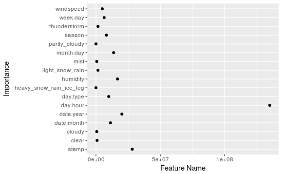

```r
feature.imp <- as.data.frame(fit.rf$importance)
feature.imp <- cbind(feature.name = rownames(feature.imp), feature.imp)
qplot(feature.imp$IncNodePurity, feature.imp$feature.name,
      xlab = 'Feature Name', ylab = 'Importance')
```

Lets run the model on our testing split.

```r
predict.rf <- predict(fit.rf, newdata = testing)
```

Lets evaluate our model

```r
RMSE(pred = predict.rf, obs = testing$count)
```

```
[1] 56.61015
```

## Model Training, Prediction & Evaluation - 2

We will use Random Forest to train our model.

First we will Configure parallel processing

```r
# clusters <- makeCluster(detectCores() - 1)
# registerDoParallel(clusters)
```

Preparing the feature dataset.

```r
# feature.train <- train.data %>%
#     select(season, atemp, humidity, windspeed, clear, partly_cloudy,
#            mist, cloudy, light_snow_rain, thunderstorm, heavy_snow_rain_ice_fog,
#            date.year, date.month, month.day, week.day, day.hour, day.type,
#            count) %>%
#     distinct()
```

Splitting training and testing datasets

```r
# set.seed(777)
# inTraining <- createDataPartition(feature.train$count, p = 0.75, list = F)
# training <- feature.train[inTraining, ]
# testing <- feature.train[-inTraining, ]
```

Setting train control and grid parameters

```r
# tr.ctrl <- trainControl(method = 'repeatedcv', number = 5, repeats = 5,
#                         verboseIter = T, allowParallel = T)
#
# grid.rf <- expand.grid(.mtry = c(2, 4, 8, 17))
```

Training model

```r
# set.seed(777)
# fit.rf <- train(x = training[, -18], y = training[, 18], method = 'rf',
#                 trControl = tr.ctrl, tuneGrid = grid.rf)
```

De-registering parallel processing cluster

```r
# stopCluster(clusters)
# registerDoSEQ()
```

Lets run the model on our testing split.

```r
#predict.rf <- predict(fit.rf, newdata = testing)
```

```r
#RMSE(pred = predict.rf, obs = testing$count)
```